# 세미나(6)

*Source file* ⇒ 세미나_6_.Rmd

## 학습목표

1. 지도학습(Supervised) vs 비지도학습(unsupervised learning): rpart vs clustering
2. 연속형 종속변수 (prediction): Linear Regression & rpart(regression)
3. 범주형 종속변수 (Classification): Logistic Regression & rpart(classification)

다음 자료는 [reference](http://rpubs.com/alucas/270689)를 참고해 작성함.

머신러닝이란 “데이터를 이용해서 컴퓨터를 학습시키는 방법론”으로 그 알고리즘은 크게 세 가지로 분류할 수 있다.

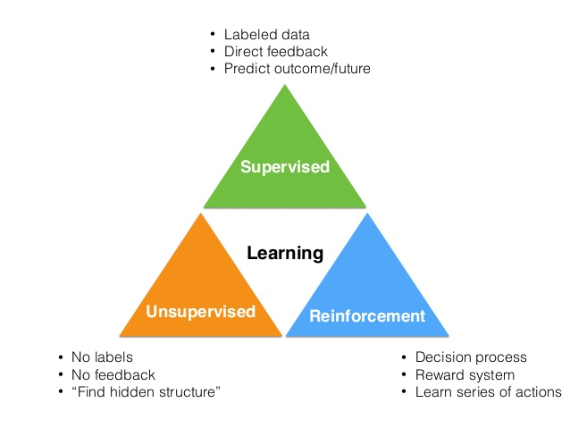

사진의 [reference](http://solarisailab.com/archives/1785)와 자세한 설명은 링크를 통해 참고.

classification과 regression은 모두 supervised(지도학습)의 하위범주에 해당된다. Classiciation과 regression은 모두 특정 Y 변수 (반응변수)가 이미 정해져 있으며 반응변수의 성질에 따라 연속형인 경우 regression 문제, 범주형일 경우 classification의 문제로 구분된다.

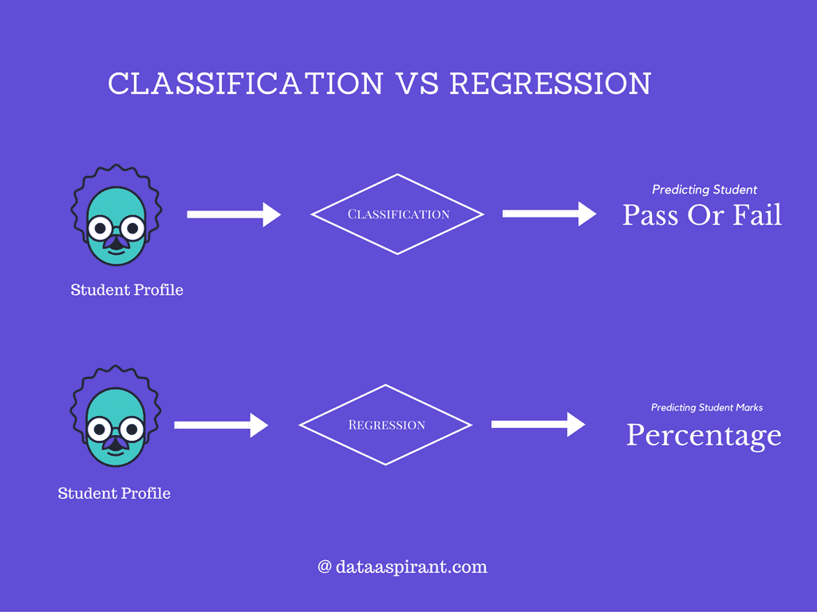

## 1. 지도학습(Supervised) vs 비지도학습(unsupervised learning)

데이터 학습의 두 가지 목표:

- 예측하기. 새로운 입력이 주어졌을 때, 그 결과가 어떻게 될 지 예측하는 것이 “예측하기”의 정확한 의미이다. 예를들어, 날씨 예측, 신용카드 사기에 대한 예측 등이 이에 포함된다. (지도학습)
- 방대한 데이터에서 패턴 찾기. (비지도학습)

### 지도학습 (aka statistical modeling)

- $i = 1, 2, 3, \ldots, n$의 여러 case가 있고 이를 **training data**이라 부른다.
- 각각의 케이스에 여러개의 독립변수(input) ${\mathbf X_i}$ 이 존재한다.
- 각각의 케이스에 종속변수(output) $Y_i$ 가 존재한다.
- 지도학습의 목표는 독립변수(들)로 부터 종속변수에 대한 결과를 “예측”하는 것이다. 따라서 독립변수와 종속변수의 관계를 찾아내는 것이 중요하다. 변수 사이의 관계는 **training data** 뿐만이 아니라 **testing data**에 대해서도 적합한 것이여야 한다. 관계는 수식으로난 다음과 같이 표현될 수 있다. $\hat{f}: \mathbf{X} \rightarrow Y$. 이를 우리는 *모델*이라고 표현하기도 한다.

예를들어, `NCHS` 데이터에서 당뇨(diabetes)과 다른 변수들이 어떠한 관계를 가지는지 알고싶다고 하자. 이때 종속변수는 `diabetic`이다.

```r
NCHS %>% select(diabetic, weight, sex, age, ethnicity, bmi) %>% head(3)
```

| diabetic | weight | sex | age | ethnicity | bmi |
| --- | --- | --- | --- | --- | --- |
| 0 | 12.5 | female | 2 | Non-Hispanic Black | 14.89769 |
| 0 | 75.4 | male | 77 | Non-Hispanic White | 24.90421 |
| 0 | 32.9 | female | 10 | Non-Hispanic White | 17.63171 |

아래는 `diabetic`과 `bmi`사이의 관계를 표현한 모델이며, 이는 지도학습에 해당한다.

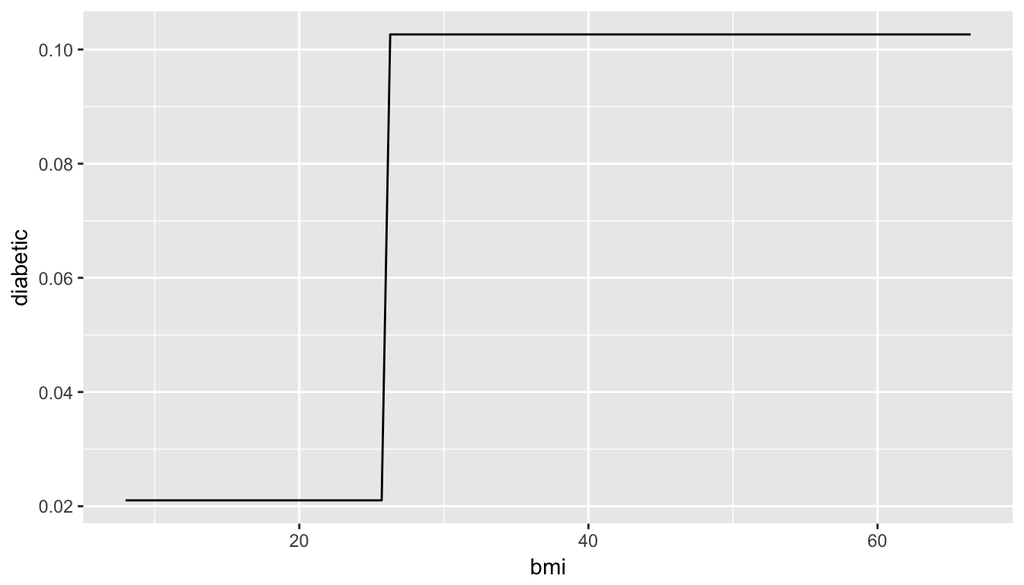

```r
#install.packages("remotes")
#library(remotes)
#install_version("statisticalModeling", "0.3.0")
library(rpart)
library(statisticalModeling)
linear_model <- rpart(diabetic~bmi, data=NCHS)
fmodel(linear_model)
```

BMI지수가 25 근방에서 당뇨지수가 크게 상승하는 것을 볼 수 있다. (2%에서 10%로) 실제로 BMI지수가 25-30 사이인 경우를 과체중으로 진단한다.

### 비지도학습

- 지도학습에서는 독립(예측)변수 $\mathbf{X}$에서 목적으로 찾고자 하는 종속변수 (output, response variable) $Y$가 존재한다. 이를 찾고자 $\hat{f}: \mathbf{X} \rightarrow Y$를 *train*시킨다.
- 비지도학습에서는 하나의 확정된 $Y$ 변수가 존재하지 않는다. 따라서 우리는 $\mathbf{X}$의 함수로 모델링을 하는 대신, $\mathbf{X}$사이에서의 패턴을 찾는다.

예를들어, 전 세계 4000개 도시들의 위도와 경도 정보를 가지고 6개의 대륙(남극을 제외한 6개의 land clusters)을 식별하고자 하는 상황을 생각해보자. 이러한 상황에서 “kmeans algorithm”을 사용하게 되는데, 이 알고리즘은 주어진 n개의 관측치(데이터)를 k개의 클러스터로 묶는 알고리즘으로, 각 클러스터와 거리 차이의 분산을 최소화하는 방식으로 동작한다.

자세한 이론은 [k-평균 알고리즘](https://ko.wikipedia.org/wiki/K-%ED%8F%89%EA%B7%A0_%EC%95%8C%EA%B3%A0%EB%A6%AC%EC%A6%98) 위키피디아 페이지를 참고.

```r
BigCities <- WorldCities %>%
  arrange(desc(population)) %>%
  head(4000) %>%
  select(longitude,latitude)
head(BigCities,3)
```

| longitude | latitude |
| --- | --- |
| 121.45806 | 31.22222 |
| -58.37723 | -34.61315 |
| 72.88261 | 19.07283 |

```r
clusters <- BigCities %>%
kmeans(centers=6)
clusters[["centers"]]
```

| longitude | latitude |
| --- | --- |
| 19.11698 | -1.46043 |
| 19.30537 | 45.13738 |
| -94.67049 | 30.67102 |
| -56.93344 | -14.78496 |
| 121.26128 | 24.17483 |
| 75.29742 | 27.58445 |

```r
clusters[["size"]]
```

```
## [1]  363  986  517  393 1020  721
```

```r
clusters[["cluster"]] %>% head(20)
```

```
##  1  2  3  4  5  6  7  8  9 10 11 12 13 14 15 16 17 18 19 20
##  5  4  6  3  6  2  6  5  2  6  5  4  1  5  5  5  3  5  1  4
```

```r
clusters <- clusters %>%
  fitted("classes") %>%
  as.character()
head(clusters)
```

```
## [1] "5" "4" "6" "3" "6" "2"
```

```r
BigCities <-  BigCities %>% mutate(cluster=clusters)
head(BigCities)
```

| longitude | latitude | cluster |
| --- | --- | --- |
| 121.45806 | 31.22222 | 5 |
| -58.37723 | -34.61315 | 4 |
| 72.88261 | 19.07283 | 6 |
| -99.12766 | 19.42847 | 3 |
| 67.08220 | 24.90560 | 6 |
| 28.94966 | 41.01384 | 2 |

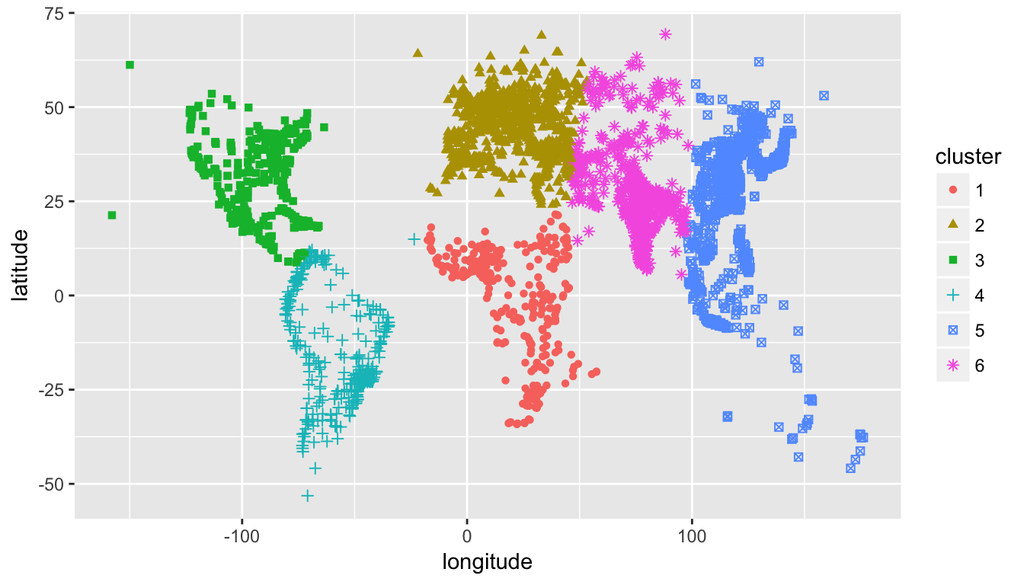

```r
BigCities %>% ggplot(aes(x=longitude, y=latitude)) + geom_point(aes(color=cluster, shape=cluster))
```

Compare to:

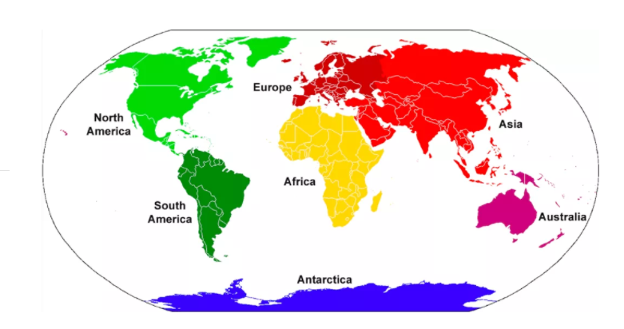

## 2. 연속형 종속변수 (prediction)

다음의 패키지를 사용하여 $Y$ 변수가 연속형인 경우 어떠한 방법론을 사용할 수 있는지 살펴보자.

```r
library(statisticalModeling)
library(rpart)
library(rpart.plot)
library(stats)
library(mosaicData)
```

$Y$ 변수가 연속형 (continuous, quantitative)인 경우 *linear regression* 혹은 *recursive partition model* 가 가장 흔히 사용되는 통계 모델이다.

### Linear Regression

linear model은 *parametric* 모델이다. 반응변수가 예측변수들과 선형의 관계를 가진다는 것을 *가정*하기 때문이다.

지난 시간 다룬 내용이므로 이론적인 부분은 생략하고, 예시를 통해 *recursive partition model* 와 어떻게 다른지 비교해보자.

`Runners`라는 데이터 테이블을 10마일 달리기 대회에 대한 정보를 포함하고 있다.

```r
Runners %>% head(3) #statisticalModeling package
```

| age | net | gun | sex | year | previous | nruns | start_position |
| --- | --- | --- | --- | --- | --- | --- | --- |
| 31 | 85.35 | 86.88 | M | 2005 | 0 | 4 | calm |
| 32 | 91.75 | 92.53 | M | 2006 | 1 | 4 | eager |
| 33 | NA | 92.40 | M | 2007 | 2 | 4 | NA |

달리기 선수들의 `net` 시간을 반응함수로 지정한다고 할 때, 반응함수는 `age` 와 `sex` 변수와 관계가 있을 것이라고 생각해볼 수 있다.

그렇다면, 다음과 같은 visualization으로 반응변수와 예측변수 사이 관계가 선형인지 확인해보자.

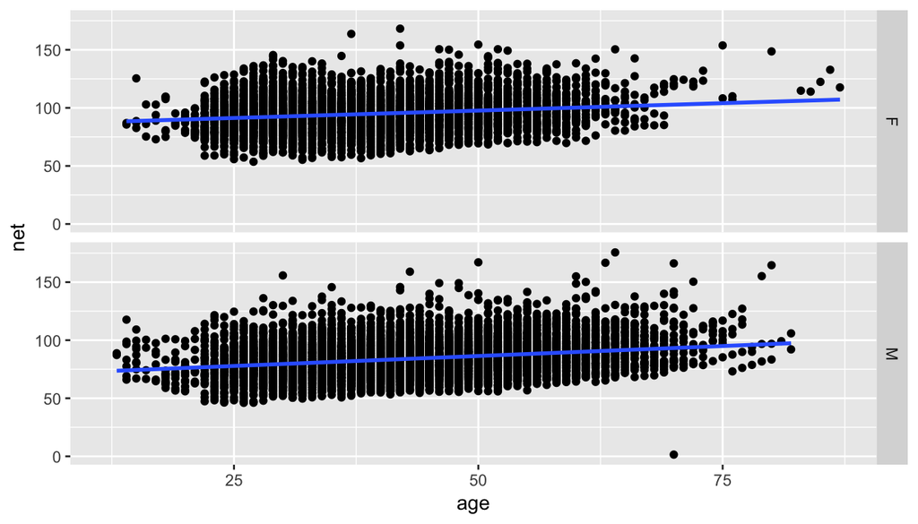

```r
Runners %>% ggplot(aes(x=age,y=net)) + geom_point() + geom_smooth(method="lm") +facet_grid(sex~.)
```

linear model의 장점은 간단하고 해석이 쉽다는 점이다. 하지만 변수들 사이 선형 관계라는 가정이 내포되어 있기 때문에 보다 유연하지 못한 모델이라는 단점이 있다.

`fmodel()`함수는 linear model의 결과를 시각적으로 보여준다.

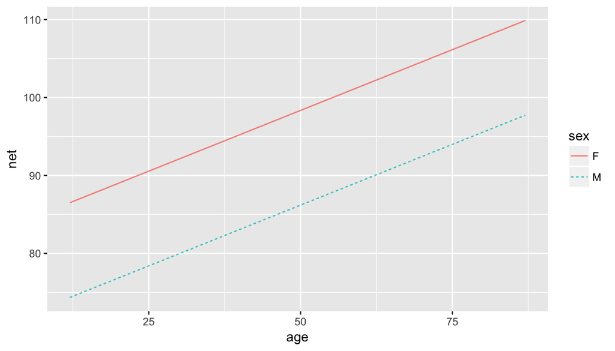

```r
lm(net~age + sex, Runners) %>% fmodel()
```

`evaluate_model()` 함수는 특정한 input에 대해 output 값을 반환해준다.

```r
lm(net~age + sex, Runners) %>%
evaluate_model(at=list(age=20, sex="M"))
```

| age | sex | model_output |
| --- | --- | --- |
| 20 | M | 76.84136 |

### Recursive Partitioning (regression)

[재귀적 분기](https://ratsgo.github.io/machine%20learning/2017/03/26/tree/)

Recursive partitioning은 *nonparametric* 모델으로 변수들 사이 어떠한 관계도 가정하지 않는다.

이 모델의 가장 큰 특징은 유사한 반응 변수의 값을 가진 관측치들이 모델링이 끝날 때 까지 계속해서 분기 과정을 거친다는 것이다. (recursively partitioned)

분기 과정이 끝나고 나면, 이 모델은 각 그룹에 대한 반응 변수의 값을 예측함다. 이 때의 최종 그룹은 우리는 잎(leaves) 혹은 terminal node라고 부른다.

앞에서 사용한 `Runners`데이터 셋을 사용하여 예시를 살펴보자. 여기서도 `net` 시간을 반응함수로 정하자. `net` 변수가 `age`와 `sex` 변수들의 함수라고 하자.

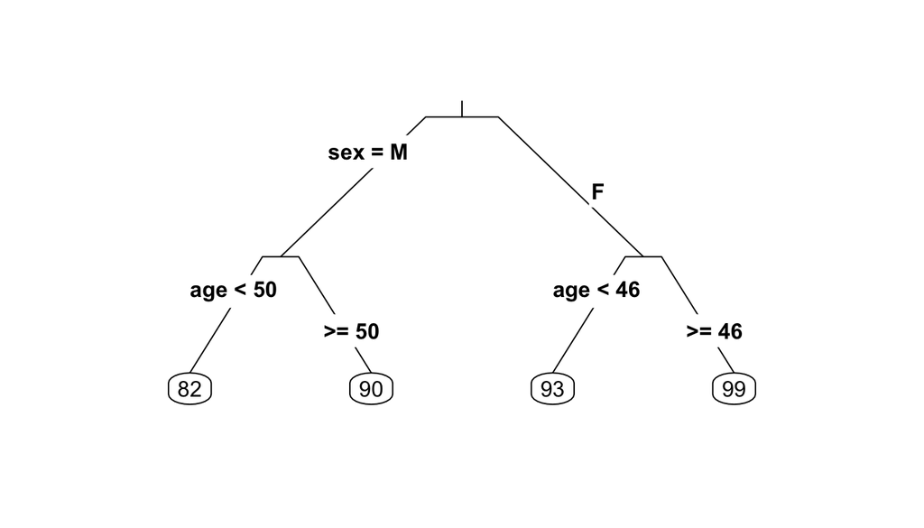

```r
rpart(net~ age + sex,  data=Runners) %>% rpart.plot::prp(type=3)
```

`sex` 변수에 따라 데이터를 구분함으로써 `net` 시간이 상당히 차이가 남을 확인할 수 있다. 성별 변수로 구분된 데이터는 `age` 변수에 의해 한 번 더 구분된다.

다음과 같이 *decision* tree (의사결정나무)를 그래프로 표현할 수 있다:

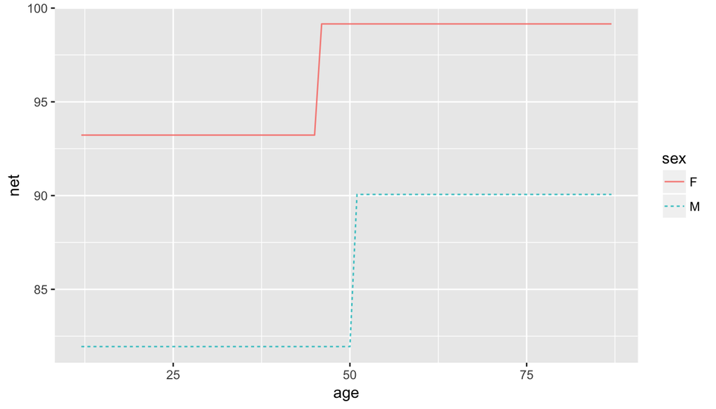

```r
rpart(net~ age + sex,  data=Runners) %>% fmodel()
```

`rpart()`함수에는 `cp` (complexity parameter)라는 옵션이 있다. `cp`는 새로운 가지를 치기 위해 반응변수에 얼마나 큰 차이가 필요한가를 정하는 parameter이다. default 값은 `cp=.02`으로 설정되어 있으며 `cp`값이 작을 수록 더 복잡한 tree를 생성한다.

더 복잡한 가지를 생성한다는 것은 그만큼 overfitting의 문제가 커질 수 있음을 의미한다. overfitting이란 모델이 너무 training dataset에 적합하게 디자인 된 상황을 의미하는데, 이런 경우 새로운 데이터에 대해서 모델이 잘 작동하지 않을 가능성이 있다.

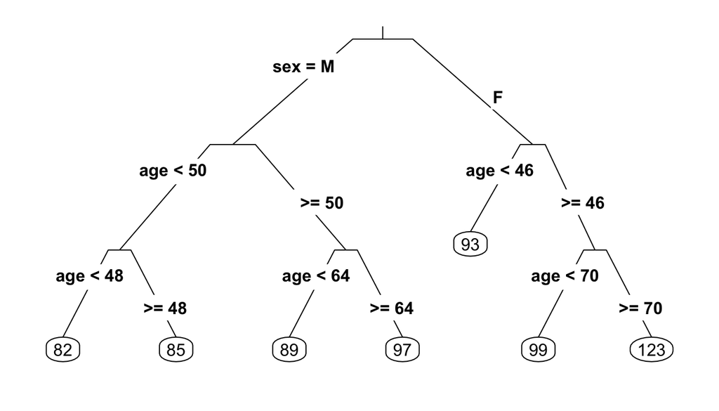

```r
rpart(net~ age + sex,  data=Runners, cp=.002) %>% rpart.plot::prp(type=3)
```

recursive partition model의 장점은 결과를 쉽게 해석할 수 있다는 점과 변수들에 대해 아무런 사전 가정을 하지 않는 다는 점이다.

## 3. 범주형 종속변수 (Classification)

### Logistic Regression

[reference](https://www.r-bloggers.com/how-to-perform-a-logistic-regression-in-r/)

- Logistic regression은 범주형 종속변수에 대한 linear regression이라고 생각할 수 있다. Logistic regression 모델은 주로 예측변수 X들을 가지고 Y를 예측할 때 사용된다. 예측변수는 연속형이거나 범주형일 수 있으며, 두 가지가 혼합된 형태일 수도 있다.
- 반응변수가 범주형이면서도 binary인 경우, 즉 (1) 혹은 (0)을 값을 가지는 상황으로 디자인 될 수 있는 경우, 우리는 이러한 문제를 “binomial logistic regression”이라고 부르며, 범주가 2개 이상인 경우는 “multinomial logistic regression”이라고 부른다. 예를들어, 이멩릴의 스팸여부를 판별 (0-스팸이 아님, 1-스팸임)을 예측하고 싶은 경우 전자에, 영화가 “매우 지루함”, “괜찮음”, “흥미로움”을 예측하고 싶은 경우는 후자에 해당한다.

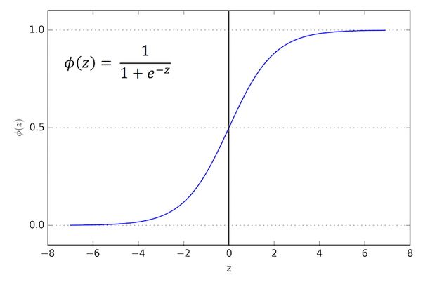

(binomial) logistic regression에서는 Y변수의 결과가 범위 [0,1]로 제한되며, Y변수가 이진적(binary)이기 때문에 조건부 확률의 분포가 정규분포 대신 이항분포를 따른다는 점이다.

데이터의 종속변수 Y의 결과는 0과 1 두 개의 경우만 존재하는데 반해, 단순 선형 회귀를 적용하면 범위 [0,1]을 벗어나는 결과가 나오기 때문에 오히려 예측의 정확도가 떨어지게 된다.

이를 해결하기 위해 logistic regresison은 연속이고 증가함수이며 [0,1]에서 값을 갖는 연결 함수 $g(x)=e^x/1+e^x$를 제안하였다.

위의 그림에서 살펴보는 것과 같이 [0,1] 사이에서 디자인된 함수를 적당한 threshold(임계점)을 가지고 나누어 그 이하를 0 그리고 그 초과를 1로 예측할 수 있다. 예를들어, 비가 올 확률에 대해 0이 비가 오지 않음, 1이 비가 옴 으로 예측하는 경우 0.5를 기준으로 그 이하의 결과를 가질 경우 0, 즉 비가 오지 않음으로 그리고 나머지의 경우를 1, 비가 옴으로 예측할 수 있다.

우리가 살펴볼 모델은 “binomial logistic regression”이다. 예시 살펴보기 위해 `titanic` 데이터를 이용하자.

```r
training.data.raw <- read.csv("/Users/jeongseohyeong/Desktop/파이썬 방학세션/4주차+랜덤포레스트/titanic.csv", header = T, na.strings=c(" "))
```

##### 데이터 전처리

```r
sapply(training.data.raw, function(x) sum(is.na(x)))
```

```
## PassengerId    Survived      Pclass        Name         Sex         Age
##           0           0           0           0           0         177
##       SibSp       Parch      Ticket        Fare       Cabin    Embarked
##           0           0           0           0           0           0
```

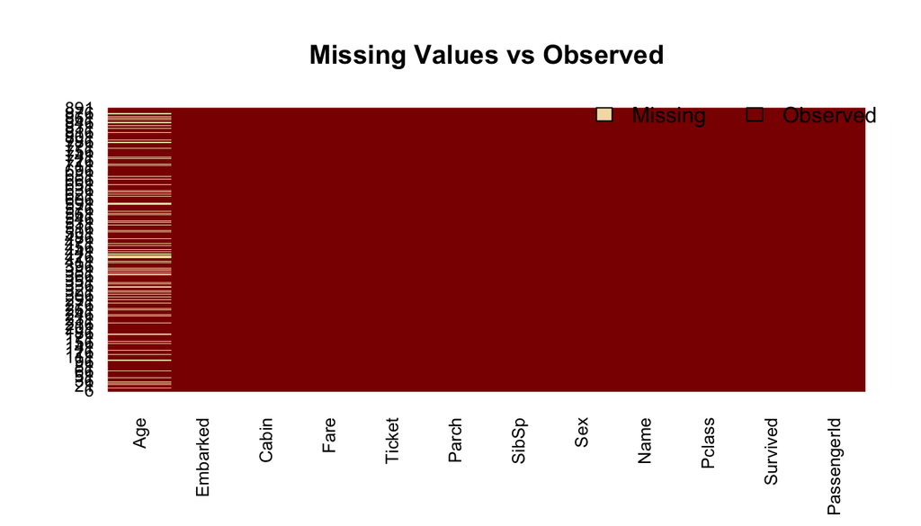

```r
library(Amelia)
missmap(training.data.raw, main = "Missing Values vs Observed")
```

```r
# select survived, pclass, sex, age, sibsp, parch, fare, embarked
data <- subset(training.data.raw, select=c(2,3,5,6,7,8,10,12))
head(data)
```

| Survived | Pclass | Sex | Age | SibSp | Parch | Fare | Embarked |
| --- | --- | --- | --- | --- | --- | --- | --- |
| 0 | 3 | male | 22 | 1 | 0 | 7.2500 | S |
| 1 | 1 | female | 38 | 1 | 0 | 71.2833 | C |
| 1 | 3 | female | 26 | 0 | 0 | 7.9250 | S |
| 1 | 1 | female | 35 | 1 | 0 | 53.1000 | S |
| 0 | 3 | male | 35 | 0 | 0 | 8.0500 | S |
| 0 | 3 | male | NA | 0 | 0 | 8.4583 | Q |

age 변수의 missing value만 처리해주면 되는데, 여기서는 missing value imputation이 주된 목적이 아니므로 평균으로 결측치를 해결한다.

```r
data$Age[is.na(data$Age)] <- mean(data$Age,na.rm=T)
```

R이 어떻게 범주형 변수를 인코딩하는지 확인하고 싶을 때는, `contrasts()`함수를 이용하여 확인할 수 있다:

```r
contrasts(data$Sex)
```

|  | male |
| --- | --- |
| female | 0 |
| male | 1 |

```r
contrasts(data$Embarked)
```

|  | C | Q | S |
| --- | --- | --- | --- |
|  | 0 | 0 | 0 |
| C | 1 | 0 | 0 |
| Q | 0 | 1 | 0 |
| S | 0 | 0 | 1 |

##### 모델링

logistic regression model 디자인에 앞서 data set을 training set과 test set으로 나누어 진행하자. training set은 모델을 디자인하는데 쓰이며, test set은 디자인한 모델을 평가하는데 쓰이게 된다.

```r
train <- data[1:800, ]
test <- data[801:891,]
```

R에서는 `glm()` 함수로 logistic regression 모델을 입력한다.

```r
model <- glm(Survived~., family=binomial(link='logit'), data=train)
```

```r
summary(model)
```

```
##
## Call:
## glm(formula = Survived ~ ., family = binomial(link = "logit"),
##     data = train)
##
## Deviance Residuals:
##     Min       1Q   Median       3Q      Max
## -2.6059  -0.5933  -0.4250   0.6215   2.4148
##
## Coefficients:
##               Estimate Std. Error z value Pr(>|z|)
## (Intercept)  15.947761 535.411378   0.030   0.9762
## Pclass       -1.087576   0.151088  -7.198 6.10e-13 ***
## Sexmale      -2.754348   0.212018 -12.991  < 2e-16 ***
## Age          -0.037244   0.008192  -4.547 5.45e-06 ***
## SibSp        -0.293478   0.114660  -2.560   0.0105 *
## Parch        -0.116828   0.128113  -0.912   0.3618
## Fare          0.001515   0.002352   0.644   0.5196
## EmbarkedC   -10.810682 535.411254  -0.020   0.9839
## EmbarkedQ   -10.812679 535.411321  -0.020   0.9839
## EmbarkedS   -11.126837 535.411236  -0.021   0.9834
## ---
## Signif. codes:  0 '***' 0.001 '**' 0.01 '*' 0.05 '.' 0.1 ' ' 1
##
## (Dispersion parameter for binomial family taken to be 1)
##
##     Null deviance: 1066.33  on 799  degrees of freedom
## Residual deviance:  708.93  on 790  degrees of freedom
## AIC: 728.93
##
## Number of Fisher Scoring iterations: 12
```

`link='logit'`은 estimated coefficient(계수)가 logit으로 표현되었음을 의미하는데, 이 때 logit이란, $ln(odds)=ln(p/(1-p))=aX_1+bX_2+...+zX_n$을 의미한다. 즉 `Sexmale`의 계수 -2.754348는 남성인 경우 logit 즉 log(odds)가 2.75 줄어든다. 반면, `age`의 경우 log(odds)가 0.037244 줄어든다.

##### 모델 평가

앞서 준비해둔 test dataset을 가지고 모델을 평가해보자.

```r
fitted.results <- predict(model,newdata=subset(test,select=c(2,3,4,5,6,7,8)),type='response') #예측값을 백터로 저장
fitted.results <- ifelse(fitted.results > 0.5,1,0) #0.5를 임계값으로 설정함, 0.5보다 크면 1로 저장하고 작으면 0으로 저장
misClasificError <- mean(fitted.results != test$Survived) #예측이 얼마나 정확한지 확인
print(paste('Accuracy',1-misClasificError))
```

```
## [1] "Accuracy 0.846153846153846"
```

0.84의 정확도면 나쁘지 않은 결과이지만 임의적으로 test dataset과 training dataset을 분류한 점, 전처리를 임의적으로 한 점 등을 고려하면 절대적으로 신뢰할만 결과라고 판단내릴 수 없다. 더욱 정확한 모델링과 평가를 위해서는 k-fold cross validation 등의 기법이 사용될 수 있다.

##### ROC Curve

마지막으로 logistic model 평가를 시각적으로 보여주는 ROC 커브를 소개하며 logistic regression을 마무리하자.

```r
library(ROCR)
```

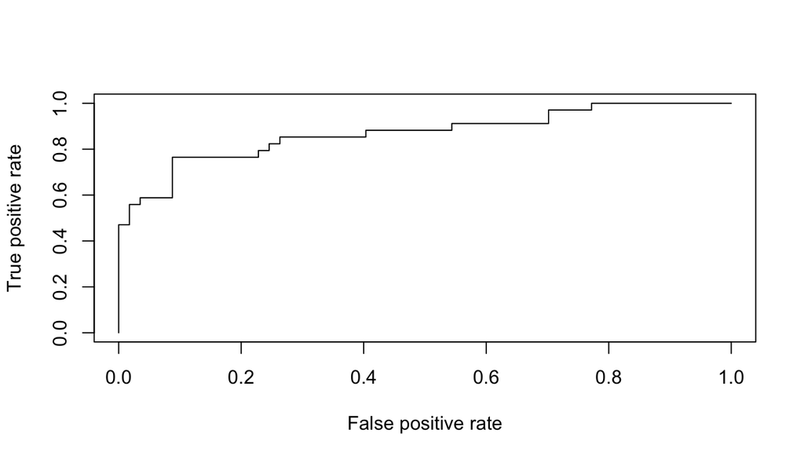

```r
p <- predict(model, newdata=subset(test,select=c(2,3,4,5,6,7,8)), type="response")
pr <- prediction(p, test$Survived)
prf <- performance(pr, measure = "tpr", x.measure = "fpr")
plot(prf)
```

```r
auc <- performance(pr, measure = "auc")
auc <- auc@y.values[[1]]
auc
```

```
## [1] 0.8684211
```

- False Positive Rate: 틀린 것을 맞다고 할 확률
- True Positive Rate: 맞는 것을 맞다고 할 확률

우리가 원하는 결과는 ’맞는 것을 맞다고 예측할 확률’을 높이는 것이다. 따라서 curve가 왼쪽 상단에 가까울 수록 좋은 모델이라고 결론지을 수 있다. 이를 수치적으로 나타내기 위해 AUC(Area Under the Curve) 해석을 사용하는데, AUC 값은 0.5에서 1의 값을 가진다. 1에 가까울 수록 커브가 왼쪽 상단에 가깝다고 볼 수 있으며 좋은 예측 능력을 가진 모델이라고 볼 수 있다.

### Recursive Partitioning (classification)

- Recursive partition model은 종속변수의 종류(범주형인지 연속형인지)와 상관없이 적용될 수 있다.

```r
head(Runners)
```

| age | net | gun | sex | year | previous | nruns | start_position |
| --- | --- | --- | --- | --- | --- | --- | --- |
| 31 | 85.35 | 86.88 | M | 2005 | 0 | 4 | calm |
| 32 | 91.75 | 92.53 | M | 2006 | 1 | 4 | eager |
| 33 | NA | 92.40 | M | 2007 | 2 | 4 | NA |
| 34 | NA | 89.28 | M | 2008 | 3 | 4 | NA |
| 25 | 67.33 | 67.48 | M | 2001 | 0 | 3 | eager |
| 26 | 70.45 | 70.70 | M | 2002 | 1 | 3 | eager |

반응변수를 `start_position`로 지정하고 반응변수가 `age`, `net` 변수들과 어떠한 관계를 가지는지 살펴보자. 이때의 문제설정은 반응변수가 범주형이기 때문에 classification의 상황이다.

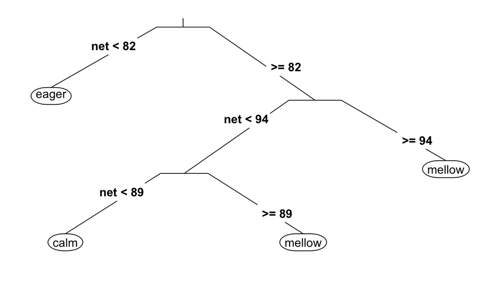

```r
rpart(start_position~net + age,data=Runners ) %>% rpart.plot::prp(type=3)
```

이 경우 `age` 변수가 트리 형성에 아무런 영향을 미치지 않는것을 확인할 수 있다.

반응변수가 범주형인 경우, 앞서 살펴본 경우와 같은 방식으로 가지가 형성되는데 범주형인 경우는 “순도”를 높이는 것을 기준으로 가지가 형성된다. 예를들어, 처음 가지에서 `net=82`를 기준으로 eager한 선수들이 대부분 걸러진 것을 볼 수 있다.

`rpart()` 함수에 특정 예측변수를 설정하지 않고 모든 변수를 예측변수로 입력하는 경우, 다음의 결과를 얻는다.

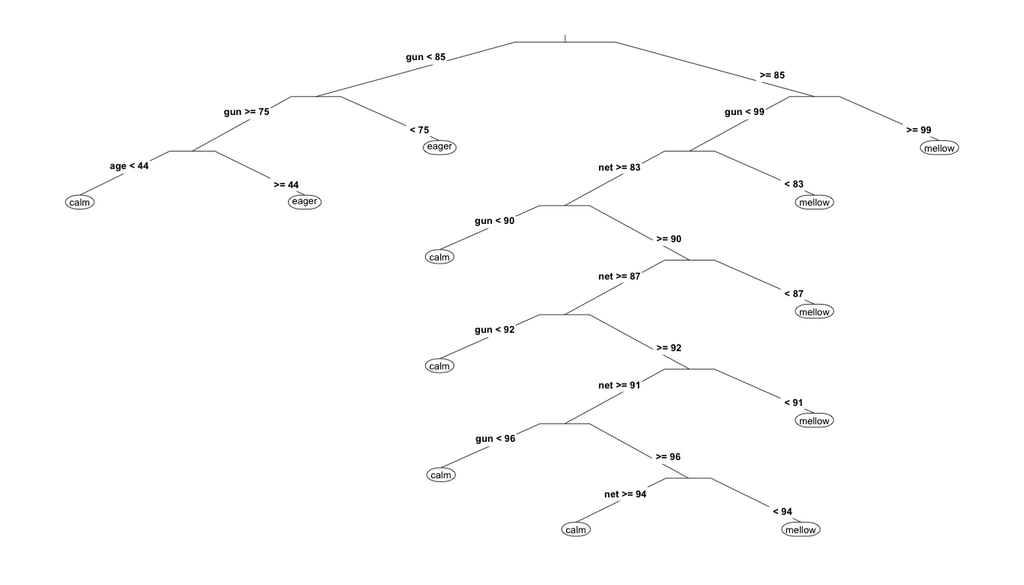

```r
rpart(start_position~.,data=Runners ) %>% rpart.plot::prp(type=3)
```

따라서 결과적으로 모든 변수를 입력하는 방식을 통해 어떤 변수들이 recursive partitioning에 중요한 역할을 하는 변수들인지 걸러낼 수 있다.